# Google Data Analytics Capstone Project

## Cyclistic: A bike-share analysis case study

[figure not shown]

```r
knitr::include_graphics("Cyclistic_Logo.png")
```

### Scenario

I am a junior data analyst working in the marketing analyst team at Cyclistic, a bike-share company in Chicago. The director of marketing (Lily Moreno) believes the company’s future success depends on maximizing the number of annual memberships. Therefore, my team wants to understand how casual riders and annual members use Cyclistic bikes differently. From these insights, my team will design a new marketing strategy to convert casual riders into annual members. But first, Cyclistic executives must approve my recommendations, so they must be backed up with compelling data insights and professional data visualizations.

### Company Background

In 2016, Cyclistic launched a successful bike-share offering. Since then, the program has grown to a fleet of 5,824 bicycles that are geotracked and locked into a network of 692 stations across Chicago. The bikes can be unlocked from one station and returned to any other station in the system anytime.

Until now, Cyclistic’s marketing strategy relied on building general awareness and appealing to broad consumer segments. One approach that helped make these things possible was the flexibility of its pricing plans: single-ride passes, full-day passes, and annual memberships. Customers who purchase single-ride or full-day passes are referred to as casual riders. Customers who purchase annual memberships are Cyclistic members.

### Step 1: Ask

#### Problem to be solved

Cyclistic’s finance analysts have concluded that annual members are much more profitable than casual riders. Although the pricing flexibility helps Cyclistic attract more customers, Moreno believes that maximizing the number of annual members will be key to future growth. Rather than creating a marketing campaign that targets all-new customers, Moreno believes there is a very good chance to convert casual riders into members. She notes that casual riders are already aware of the Cyclistic program and have chosen Cyclistic for their mobility needs.

Moreno has set a clear goal: Design marketing strategies aimed at converting casual riders into annual members. In order to do that, however, the marketing analyst team needs to better understand how annual members and casual riders differ, why casual riders would buy a membership, and how digital media could affect their marketing tactics. Moreno and her team are interested in analyzing the Cyclistic historical bike trip data to identify trends.

#### Business task

- How do annual members and casual riders use Cyclistic bikes differently?

#### Key Stakeholders

- Lily Moreno: Director of Marketing
- Executive leadership team for Cyclistic

### Step 2: Prepare

#### Data Origination

- Cyclistic data located here: https://divvy-tripdata.s3.amazonaws.com/index.html
- Data license provided by Motivate InternatIONAL Inc under the following license: https://ride.divvybikes.com/data-license-agreement

#### Data Preparation

I chose to complete my data preparation and cleaning using R Studio. Here are the packages I”m using for this project:

```r
library(tidyverse)
```

```r
library(ggplot2)
library(readr)
library(dplyr)
library(stringr)
library(lubridate)
library(data.table)
library(janitor)
library(tidyr)
```

Next, I loaded in the CSV data files that I’ll be working from.

```r
Trips_Sept_21 <- read_csv("202109-divvy-tripdata.csv")
Trips_Oct_21 <- read_csv("202110-divvy-tripdata.csv")
Trips_Nov_21 <- read_csv("202111-divvy-tripdata.csv")
Trips_Dec_21 <- read_csv("202112-divvy-tripdata.csv")
Trips_Jan_22 <- read_csv("202201-divvy-tripdata.csv")
Trips_Feb_22 <- read_csv("202202-divvy-tripdata.csv")
Trips_Mar_22 <- read_csv("202203-divvy-tripdata.csv")
Trips_Apr_22 <- read_csv("202204-divvy-tripdata.csv")
Trips_May_22 <- read_csv("202205-divvy-tripdata.csv")
Trips_Jun_22 <- read_csv("202206-divvy-tripdata.csv")
Trips_Jul_22 <- read_csv("202207-divvy-tripdata.csv")
Trips_Aug_22 <- read_csv("202208-divvy-tripdata.csv")
```

After getting all of the CSVs loaded I’m checking the data structure for each data set using the str() function.

```r
str(Trips_Sept_21)
```

```
## spec_tbl_df [756,147 × 13] (S3: spec_tbl_df/tbl_df/tbl/data.frame)
##  $ ride_id           : chr [1:756147] "9DC7B962304CBFD8" "F930E2C6872D6B32" "6EF72137900BB910" "78D1DE133B3DBF55" ...
##  $ rideable_type     : chr [1:756147] "electric_bike" "electric_bike" "electric_bike" "electric_bike" ...
##  $ started_at        : POSIXct[1:756147], format: "2021-09-28 16:07:10" "2021-09-28 14:24:51" ...
##  $ ended_at          : POSIXct[1:756147], format: "2021-09-28 16:09:54" "2021-09-28 14:40:05" ...
##  $ start_station_name: chr [1:756147] NA NA NA NA ...
##  $ start_station_id  : chr [1:756147] NA NA NA NA ...
##  $ end_station_name  : chr [1:756147] NA NA NA NA ...
##  $ end_station_id    : chr [1:756147] NA NA NA NA ...
##  $ start_lat         : num [1:756147] 41.9 41.9 41.8 41.8 41.9 ...
##  $ start_lng         : num [1:756147] -87.7 -87.6 -87.7 -87.7 -87.7 ...
##  $ end_lat           : num [1:756147] 41.9 42 41.8 41.8 41.9 ...
##  $ end_lng           : num [1:756147] -87.7 -87.7 -87.7 -87.7 -87.7 ...
##  $ member_casual     : chr [1:756147] "casual" "casual" "casual" "casual" ...
##  - attr(*, "spec")=
##   .. cols(
##   ..   ride_id = col_character(),
##   ..   rideable_type = col_character(),
##   ..   started_at = col_datetime(format = ""),
##   ..   ended_at = col_datetime(format = ""),
##   ..   start_station_name = col_character(),
##   ..   start_station_id = col_character(),
##   ..   end_station_name = col_character(),
##   ..   end_station_id = col_character(),
##   ..   start_lat = col_double(),
##   ..   start_lng = col_double(),
##   ..   end_lat = col_double(),
##   ..   end_lng = col_double(),
##   ..   member_casual = col_character()
##   .. )
##  - attr(*, "problems")=<externalptr>
```

```r
str(Trips_Oct_21)
```

```
## spec_tbl_df [631,226 × 13] (S3: spec_tbl_df/tbl_df/tbl/data.frame)
##  $ ride_id           : chr [1:631226] "620BC6107255BF4C" "4471C70731AB2E45" "26CA69D43D15EE14" "362947F0437E1514" ...
##  $ rideable_type     : chr [1:631226] "electric_bike" "electric_bike" "electric_bike" "electric_bike" ...
##  $ started_at        : POSIXct[1:631226], format: "2021-10-22 12:46:42" "2021-10-21 09:12:37" ...
##  $ ended_at          : POSIXct[1:631226], format: "2021-10-22 12:49:50" "2021-10-21 09:14:14" ...
##  $ start_station_name: chr [1:631226] "Kingsbury St & Kinzie St" NA NA NA ...
##  $ start_station_id  : chr [1:631226] "KA1503000043" NA NA NA ...
##  $ end_station_name  : chr [1:631226] NA NA NA NA ...
##  $ end_station_id    : chr [1:631226] NA NA NA NA ...
##  $ start_lat         : num [1:631226] 41.9 41.9 41.9 41.9 41.9 ...
##  $ start_lng         : num [1:631226] -87.6 -87.7 -87.7 -87.7 -87.7 ...
##  $ end_lat           : num [1:631226] 41.9 41.9 41.9 41.9 41.9 ...
##  $ end_lng           : num [1:631226] -87.6 -87.7 -87.7 -87.7 -87.7 ...
##  $ member_casual     : chr [1:631226] "member" "member" "member" "member" ...
##  - attr(*, "spec")=
##   .. cols(
##   ..   ride_id = col_character(),
##   ..   rideable_type = col_character(),
##   ..   started_at = col_datetime(format = ""),
##   ..   ended_at = col_datetime(format = ""),
##   ..   start_station_name = col_character(),
##   ..   start_station_id = col_character(),
##   ..   end_station_name = col_character(),
##   ..   end_station_id = col_character(),
##   ..   start_lat = col_double(),
##   ..   start_lng = col_double(),
##   ..   end_lat = col_double(),
##   ..   end_lng = col_double(),
##   ..   member_casual = col_character()
##   .. )
##  - attr(*, "problems")=<externalptr>
```

```r
str(Trips_Nov_21)
```

```
## spec_tbl_df [359,978 × 13] (S3: spec_tbl_df/tbl_df/tbl/data.frame)
##  $ ride_id           : chr [1:359978] "7C00A93E10556E47" "90854840DFD508BA" "0A7D10CDD144061C" "2F3BE33085BCFF02" ...
##  $ rideable_type     : chr [1:359978] "electric_bike" "electric_bike" "electric_bike" "electric_bike" ...
##  $ started_at        : POSIXct[1:359978], format: "2021-11-27 13:27:38" "2021-11-27 13:38:25" ...
##  $ ended_at          : POSIXct[1:359978], format: "2021-11-27 13:46:38" "2021-11-27 13:56:10" ...
##  $ start_station_name: chr [1:359978] NA NA NA NA ...
##  $ start_station_id  : chr [1:359978] NA NA NA NA ...
##  $ end_station_name  : chr [1:359978] NA NA NA NA ...
##  $ end_station_id    : chr [1:359978] NA NA NA NA ...
##  $ start_lat         : num [1:359978] 41.9 42 42 41.9 41.9 ...
##  $ start_lng         : num [1:359978] -87.7 -87.7 -87.7 -87.8 -87.6 ...
##  $ end_lat           : num [1:359978] 42 41.9 42 41.9 41.9 ...
##  $ end_lng           : num [1:359978] -87.7 -87.7 -87.7 -87.8 -87.6 ...
##  $ member_casual     : chr [1:359978] "casual" "casual" "casual" "casual" ...
##  - attr(*, "spec")=
##   .. cols(
##   ..   ride_id = col_character(),
##   ..   rideable_type = col_character(),
##   ..   started_at = col_datetime(format = ""),
##   ..   ended_at = col_datetime(format = ""),
##   ..   start_station_name = col_character(),
##   ..   start_station_id = col_character(),
##   ..   end_station_name = col_character(),
##   ..   end_station_id = col_character(),
##   ..   start_lat = col_double(),
##   ..   start_lng = col_double(),
##   ..   end_lat = col_double(),
##   ..   end_lng = col_double(),
##   ..   member_casual = col_character()
##   .. )
##  - attr(*, "problems")=<externalptr>
```

```r
str(Trips_Jan_22)
```

```
## spec_tbl_df [103,770 × 13] (S3: spec_tbl_df/tbl_df/tbl/data.frame)
##  $ ride_id           : chr [1:103770] "C2F7DD78E82EC875" "A6CF8980A652D272" "BD0F91DFF741C66D" "CBB80ED419105406" ...
##  $ rideable_type     : chr [1:103770] "electric_bike" "electric_bike" "classic_bike" "classic_bike" ...
##  $ started_at        : POSIXct[1:103770], format: "2022-01-13 11:59:47" "2022-01-10 08:41:56" ...
##  $ ended_at          : POSIXct[1:103770], format: "2022-01-13 12:02:44" "2022-01-10 08:46:17" ...
##  $ start_station_name: chr [1:103770] "Glenwood Ave & Touhy Ave" "Glenwood Ave & Touhy Ave" "Sheffield Ave & Fullerton Ave" "Clark St & Bryn Mawr Ave" ...
##  $ start_station_id  : chr [1:103770] "525" "525" "TA1306000016" "KA1504000151" ...
##  $ end_station_name  : chr [1:103770] "Clark St & Touhy Ave" "Clark St & Touhy Ave" "Greenview Ave & Fullerton Ave" "Paulina St & Montrose Ave" ...
##  $ end_station_id    : chr [1:103770] "RP-007" "RP-007" "TA1307000001" "TA1309000021" ...
##  $ start_lat         : num [1:103770] 42 42 41.9 42 41.9 ...
##  $ start_lng         : num [1:103770] -87.7 -87.7 -87.7 -87.7 -87.6 ...
##  $ end_lat           : num [1:103770] 42 42 41.9 42 41.9 ...
##  $ end_lng           : num [1:103770] -87.7 -87.7 -87.7 -87.7 -87.6 ...
##  $ member_casual     : chr [1:103770] "casual" "casual" "member" "casual" ...
##  - attr(*, "spec")=
##   .. cols(
##   ..   ride_id = col_character(),
##   ..   rideable_type = col_character(),
##   ..   started_at = col_datetime(format = ""),
##   ..   ended_at = col_datetime(format = ""),
##   ..   start_station_name = col_character(),
##   ..   start_station_id = col_character(),
##   ..   end_station_name = col_character(),
##   ..   end_station_id = col_character(),
##   ..   start_lat = col_double(),
##   ..   start_lng = col_double(),
##   ..   end_lat = col_double(),
##   ..   end_lng = col_double(),
##   ..   member_casual = col_character()
##   .. )
##  - attr(*, "problems")=<externalptr>
```

```r
str(Trips_Feb_22)
```

```
## spec_tbl_df [115,609 × 13] (S3: spec_tbl_df/tbl_df/tbl/data.frame)
##  $ ride_id           : chr [1:115609] "E1E065E7ED285C02" "1602DCDC5B30FFE3" "BE7DD2AF4B55C4AF" "A1789BDF844412BE" ...
##  $ rideable_type     : chr [1:115609] "classic_bike" "classic_bike" "classic_bike" "classic_bike" ...
##  $ started_at        : POSIXct[1:115609], format: "2022-02-19 18:08:41" "2022-02-20 17:41:30" ...
##  $ ended_at          : POSIXct[1:115609], format: "2022-02-19 18:23:56" "2022-02-20 17:45:56" ...
##  $ start_station_name: chr [1:115609] "State St & Randolph St" "Halsted St & Wrightwood Ave" "State St & Randolph St" "Southport Ave & Waveland Ave" ...
##  $ start_station_id  : chr [1:115609] "TA1305000029" "TA1309000061" "TA1305000029" "13235" ...
##  $ end_station_name  : chr [1:115609] "Clark St & Lincoln Ave" "Southport Ave & Wrightwood Ave" "Canal St & Adams St" "Broadway & Sheridan Rd" ...
##  $ end_station_id    : chr [1:115609] "13179" "TA1307000113" "13011" "13323" ...
##  $ start_lat         : num [1:115609] 41.9 41.9 41.9 41.9 41.9 ...
##  $ start_lng         : num [1:115609] -87.6 -87.6 -87.6 -87.7 -87.6 ...
##  $ end_lat           : num [1:115609] 41.9 41.9 41.9 42 41.9 ...
##  $ end_lng           : num [1:115609] -87.6 -87.7 -87.6 -87.6 -87.6 ...
##  $ member_casual     : chr [1:115609] "member" "member" "member" "member" ...
##  - attr(*, "spec")=
##   .. cols(
##   ..   ride_id = col_character(),
##   ..   rideable_type = col_character(),
##   ..   started_at = col_datetime(format = ""),
##   ..   ended_at = col_datetime(format = ""),
##   ..   start_station_name = col_character(),
##   ..   start_station_id = col_character(),
##   ..   end_station_name = col_character(),
##   ..   end_station_id = col_character(),
##   ..   start_lat = col_double(),
##   ..   start_lng = col_double(),
##   ..   end_lat = col_double(),
##   ..   end_lng = col_double(),
##   ..   member_casual = col_character()
##   .. )
##  - attr(*, "problems")=<externalptr>
```

```r
str(Trips_Mar_22)
```

```
## spec_tbl_df [284,042 × 13] (S3: spec_tbl_df/tbl_df/tbl/data.frame)
##  $ ride_id           : chr [1:284042] "47EC0A7F82E65D52" "8494861979B0F477" "EFE527AF80B66109" "9F446FD9DEE3F389" ...
##  $ rideable_type     : chr [1:284042] "classic_bike" "electric_bike" "classic_bike" "classic_bike" ...
##  $ started_at        : POSIXct[1:284042], format: "2022-03-21 13:45:01" "2022-03-16 09:37:16" ...
##  $ ended_at          : POSIXct[1:284042], format: "2022-03-21 13:51:18" "2022-03-16 09:43:34" ...
##  $ start_station_name: chr [1:284042] "Wabash Ave & Wacker Pl" "Michigan Ave & Oak St" "Broadway & Berwyn Ave" "Wabash Ave & Wacker Pl" ...
##  $ start_station_id  : chr [1:284042] "TA1307000131" "13042" "13109" "TA1307000131" ...
##  $ end_station_name  : chr [1:284042] "Kingsbury St & Kinzie St" "Orleans St & Chestnut St (NEXT Apts)" "Broadway & Ridge Ave" "Franklin St & Jackson Blvd" ...
##  $ end_station_id    : chr [1:284042] "KA1503000043" "620" "15578" "TA1305000025" ...
##  $ start_lat         : num [1:284042] 41.9 41.9 42 41.9 41.9 ...
##  $ start_lng         : num [1:284042] -87.6 -87.6 -87.7 -87.6 -87.6 ...
##  $ end_lat           : num [1:284042] 41.9 41.9 42 41.9 41.9 ...
##  $ end_lng           : num [1:284042] -87.6 -87.6 -87.7 -87.6 -87.7 ...
##  $ member_casual     : chr [1:284042] "member" "member" "member" "member" ...
##  - attr(*, "spec")=
##   .. cols(
##   ..   ride_id = col_character(),
##   ..   rideable_type = col_character(),
##   ..   started_at = col_datetime(format = ""),
##   ..   ended_at = col_datetime(format = ""),
##   ..   start_station_name = col_character(),
##   ..   start_station_id = col_character(),
##   ..   end_station_name = col_character(),
##   ..   end_station_id = col_character(),
##   ..   start_lat = col_double(),
##   ..   start_lng = col_double(),
##   ..   end_lat = col_double(),
##   ..   end_lng = col_double(),
##   ..   member_casual = col_character()
##   .. )
##  - attr(*, "problems")=<externalptr>
```

```r
str(Trips_Apr_22)
```

```
## spec_tbl_df [371,249 × 13] (S3: spec_tbl_df/tbl_df/tbl/data.frame)
##  $ ride_id           : chr [1:371249] "3564070EEFD12711" "0B820C7FCF22F489" "89EEEE32293F07FF" "84D4751AEB31888D" ...
##  $ rideable_type     : chr [1:371249] "electric_bike" "classic_bike" "classic_bike" "classic_bike" ...
##  $ started_at        : POSIXct[1:371249], format: "2022-04-06 17:42:48" "2022-04-24 19:23:07" ...
##  $ ended_at          : POSIXct[1:371249], format: "2022-04-06 17:54:36" "2022-04-24 19:43:17" ...
##  $ start_station_name: chr [1:371249] "Paulina St & Howard St" "Wentworth Ave & Cermak Rd" "Halsted St & Polk St" "Wentworth Ave & Cermak Rd" ...
##  $ start_station_id  : chr [1:371249] "515" "13075" "TA1307000121" "13075" ...
##  $ end_station_name  : chr [1:371249] "University Library (NU)" "Green St & Madison St" "Green St & Madison St" "Delano Ct & Roosevelt Rd" ...
##  $ end_station_id    : chr [1:371249] "605" "TA1307000120" "TA1307000120" "KA1706005007" ...
##  $ start_lat         : num [1:371249] 42 41.9 41.9 41.9 41.9 ...
##  $ start_lng         : num [1:371249] -87.7 -87.6 -87.6 -87.6 -87.6 ...
##  $ end_lat           : num [1:371249] 42.1 41.9 41.9 41.9 41.9 ...
##  $ end_lng           : num [1:371249] -87.7 -87.6 -87.6 -87.6 -87.6 ...
##  $ member_casual     : chr [1:371249] "member" "member" "member" "casual" ...
##  - attr(*, "spec")=
##   .. cols(
##   ..   ride_id = col_character(),
##   ..   rideable_type = col_character(),
##   ..   started_at = col_datetime(format = ""),
##   ..   ended_at = col_datetime(format = ""),
##   ..   start_station_name = col_character(),
##   ..   start_station_id = col_character(),
##   ..   end_station_name = col_character(),
##   ..   end_station_id = col_character(),
##   ..   start_lat = col_double(),
##   ..   start_lng = col_double(),
##   ..   end_lat = col_double(),
##   ..   end_lng = col_double(),
##   ..   member_casual = col_character()
##   .. )
##  - attr(*, "problems")=<externalptr>
```

```r
str(Trips_May_22)
```

```
## spec_tbl_df [634,858 × 13] (S3: spec_tbl_df/tbl_df/tbl/data.frame)
##  $ ride_id           : chr [1:634858] "EC2DE40644C6B0F4" "1C31AD03897EE385" "1542FBEC830415CF" "6FF59852924528F8" ...
##  $ rideable_type     : chr [1:634858] "classic_bike" "classic_bike" "classic_bike" "classic_bike" ...
##  $ started_at        : POSIXct[1:634858], format: "2022-05-23 23:06:58" "2022-05-11 08:53:28" ...
##  $ ended_at          : POSIXct[1:634858], format: "2022-05-23 23:40:19" "2022-05-11 09:31:22" ...
##  $ start_station_name: chr [1:634858] "Wabash Ave & Grand Ave" "DuSable Lake Shore Dr & Monroe St" "Clinton St & Madison St" "Clinton St & Madison St" ...
##  $ start_station_id  : chr [1:634858] "TA1307000117" "13300" "TA1305000032" "TA1305000032" ...
##  $ end_station_name  : chr [1:634858] "Halsted St & Roscoe St" "Field Blvd & South Water St" "Wood St & Milwaukee Ave" "Clark St & Randolph St" ...
##  $ end_station_id    : chr [1:634858] "TA1309000025" "15534" "13221" "TA1305000030" ...
##  $ start_lat         : num [1:634858] 41.9 41.9 41.9 41.9 41.9 ...
##  $ start_lng         : num [1:634858] -87.6 -87.6 -87.6 -87.6 -87.6 ...
##  $ end_lat           : num [1:634858] 41.9 41.9 41.9 41.9 41.9 ...
##  $ end_lng           : num [1:634858] -87.6 -87.6 -87.7 -87.6 -87.7 ...
##  $ member_casual     : chr [1:634858] "member" "member" "member" "member" ...
##  - attr(*, "spec")=
##   .. cols(
##   ..   ride_id = col_character(),
##   ..   rideable_type = col_character(),
##   ..   started_at = col_datetime(format = ""),
##   ..   ended_at = col_datetime(format = ""),
##   ..   start_station_name = col_character(),
##   ..   start_station_id = col_character(),
##   ..   end_station_name = col_character(),
##   ..   end_station_id = col_character(),
##   ..   start_lat = col_double(),
##   ..   start_lng = col_double(),
##   ..   end_lat = col_double(),
##   ..   end_lng = col_double(),
##   ..   member_casual = col_character()
##   .. )
##  - attr(*, "problems")=<externalptr>
```

```r
str(Trips_Jun_22)
```

```
## spec_tbl_df [769,204 × 13] (S3: spec_tbl_df/tbl_df/tbl/data.frame)
##  $ ride_id           : chr [1:769204] "600CFD130D0FD2A4" "F5E6B5C1682C6464" "B6EB6D27BAD771D2" "C9C320375DE1D5C6" ...
##  $ rideable_type     : chr [1:769204] "electric_bike" "electric_bike" "electric_bike" "electric_bike" ...
##  $ started_at        : POSIXct[1:769204], format: "2022-06-30 17:27:53" "2022-06-30 18:39:52" ...
##  $ ended_at          : POSIXct[1:769204], format: "2022-06-30 17:35:15" "2022-06-30 18:47:28" ...
##  $ start_station_name: chr [1:769204] NA NA NA NA ...
##  $ start_station_id  : chr [1:769204] NA NA NA NA ...
##  $ end_station_name  : chr [1:769204] NA NA NA NA ...
##  $ end_station_id    : chr [1:769204] NA NA NA NA ...
##  $ start_lat         : num [1:769204] 41.9 41.9 41.9 41.8 41.9 ...
##  $ start_lng         : num [1:769204] -87.6 -87.6 -87.7 -87.7 -87.6 ...
##  $ end_lat           : num [1:769204] 41.9 41.9 41.9 41.8 41.9 ...
##  $ end_lng           : num [1:769204] -87.6 -87.6 -87.6 -87.7 -87.6 ...
##  $ member_casual     : chr [1:769204] "casual" "casual" "casual" "casual" ...
##  - attr(*, "spec")=
##   .. cols(
##   ..   ride_id = col_character(),
##   ..   rideable_type = col_character(),
##   ..   started_at = col_datetime(format = ""),
##   ..   ended_at = col_datetime(format = ""),
##   ..   start_station_name = col_character(),
##   ..   start_station_id = col_character(),
##   ..   end_station_name = col_character(),
##   ..   end_station_id = col_character(),
##   ..   start_lat = col_double(),
##   ..   start_lng = col_double(),
##   ..   end_lat = col_double(),
##   ..   end_lng = col_double(),
##   ..   member_casual = col_character()
##   .. )
##  - attr(*, "problems")=<externalptr>
```

```r
str(Trips_Jun_22)
```

```
## spec_tbl_df [769,204 × 13] (S3: spec_tbl_df/tbl_df/tbl/data.frame)
##  $ ride_id           : chr [1:769204] "600CFD130D0FD2A4" "F5E6B5C1682C6464" "B6EB6D27BAD771D2" "C9C320375DE1D5C6" ...
##  $ rideable_type     : chr [1:769204] "electric_bike" "electric_bike" "electric_bike" "electric_bike" ...
##  $ started_at        : POSIXct[1:769204], format: "2022-06-30 17:27:53" "2022-06-30 18:39:52" ...
##  $ ended_at          : POSIXct[1:769204], format: "2022-06-30 17:35:15" "2022-06-30 18:47:28" ...
##  $ start_station_name: chr [1:769204] NA NA NA NA ...
##  $ start_station_id  : chr [1:769204] NA NA NA NA ...
##  $ end_station_name  : chr [1:769204] NA NA NA NA ...
##  $ end_station_id    : chr [1:769204] NA NA NA NA ...
##  $ start_lat         : num [1:769204] 41.9 41.9 41.9 41.8 41.9 ...
##  $ start_lng         : num [1:769204] -87.6 -87.6 -87.7 -87.7 -87.6 ...
##  $ end_lat           : num [1:769204] 41.9 41.9 41.9 41.8 41.9 ...
##  $ end_lng           : num [1:769204] -87.6 -87.6 -87.6 -87.7 -87.6 ...
##  $ member_casual     : chr [1:769204] "casual" "casual" "casual" "casual" ...
##  - attr(*, "spec")=
##   .. cols(
##   ..   ride_id = col_character(),
##   ..   rideable_type = col_character(),
##   ..   started_at = col_datetime(format = ""),
##   ..   ended_at = col_datetime(format = ""),
##   ..   start_station_name = col_character(),
##   ..   start_station_id = col_character(),
##   ..   end_station_name = col_character(),
##   ..   end_station_id = col_character(),
##   ..   start_lat = col_double(),
##   ..   start_lng = col_double(),
##   ..   end_lat = col_double(),
##   ..   end_lng = col_double(),
##   ..   member_casual = col_character()
##   .. )
##  - attr(*, "problems")=<externalptr>
```

```r
str(Trips_Aug_22)
```

```
## spec_tbl_df [785,932 × 13] (S3: spec_tbl_df/tbl_df/tbl/data.frame)
##  $ ride_id           : chr [1:785932] "550CF7EFEAE0C618" "DAD198F405F9C5F5" "E6F2BC47B65CB7FD" "F597830181C2E13C" ...
##  $ rideable_type     : chr [1:785932] "electric_bike" "electric_bike" "electric_bike" "electric_bike" ...
##  $ started_at        : POSIXct[1:785932], format: "2022-08-07 21:34:15" "2022-08-08 14:39:21" ...
##  $ ended_at          : POSIXct[1:785932], format: "2022-08-07 21:41:46" "2022-08-08 14:53:23" ...
##  $ start_station_name: chr [1:785932] NA NA NA NA ...
##  $ start_station_id  : chr [1:785932] NA NA NA NA ...
##  $ end_station_name  : chr [1:785932] NA NA NA NA ...
##  $ end_station_id    : chr [1:785932] NA NA NA NA ...
##  $ start_lat         : num [1:785932] 41.9 41.9 42 41.9 41.9 ...
##  $ start_lng         : num [1:785932] -87.7 -87.6 -87.7 -87.7 -87.7 ...
##  $ end_lat           : num [1:785932] 41.9 41.9 42 42 41.8 ...
##  $ end_lng           : num [1:785932] -87.7 -87.6 -87.7 -87.7 -87.7 ...
##  $ member_casual     : chr [1:785932] "casual" "casual" "casual" "casual" ...
##  - attr(*, "spec")=
##   .. cols(
##   ..   ride_id = col_character(),
##   ..   rideable_type = col_character(),
##   ..   started_at = col_datetime(format = ""),
##   ..   ended_at = col_datetime(format = ""),
##   ..   start_station_name = col_character(),
##   ..   start_station_id = col_character(),
##   ..   end_station_name = col_character(),
##   ..   end_station_id = col_character(),
##   ..   start_lat = col_double(),
##   ..   start_lng = col_double(),
##   ..   end_lat = col_double(),
##   ..   end_lng = col_double(),
##   ..   member_casual = col_character()
##   .. )
##  - attr(*, "problems")=<externalptr>
```

```r
compare_df_cols(Trips_Sept_21, Trips_Oct_21, Trips_Nov_21, Trips_Dec_21, Trips_Jan_22, Trips_Feb_22, Trips_Mar_22, Trips_Apr_22, Trips_May_22, Trips_Jun_22, Trips_Jul_22, Trips_Aug_22, return = "mismatch")
```

| column_name | Trips_Sept_21 | Trips_Oct_21 | Trips_Nov_21 | Trips_Dec_21 | Trips_Jan_22 | Trips_Feb_22 | Trips_Mar_22 | Trips_Apr_22 | Trips_May_22 | Trips_Jun_22 | Trips_Jul_22 | Trips_Aug_22 |
| --- | --- | --- | --- | --- | --- | --- | --- | --- | --- | --- | --- | --- |

```r
Trips_Oct_21$started_at <- lubridate::mdy_hm(Trips_Oct_21$started_at)
Trips_Oct_21$ended_at <- lubridate::mdy_hm(Trips_Oct_21$ended_at)
```

Now I’ll re-check the data types for the columns in each data set using the compare_df_cols() function again.

```r
compare_df_cols(Trips_Sept_21, Trips_Oct_21, Trips_Nov_21, Trips_Dec_21, Trips_Jan_22, Trips_Feb_22, Trips_Mar_22, Trips_Apr_22, Trips_May_22, Trips_Jun_22, Trips_Jul_22, Trips_Aug_22, return = "mismatch")
```

| column_name | Trips_Sept_21 | Trips_Oct_21 | Trips_Nov_21 | Trips_Dec_21 | Trips_Jan_22 | Trips_Feb_22 | Trips_Mar_22 | Trips_Apr_22 | Trips_May_22 | Trips_Jun_22 | Trips_Jul_22 | Trips_Aug_22 |
| --- | --- | --- | --- | --- | --- | --- | --- | --- | --- | --- | --- | --- |

The data types and column numbers now match for each data set.

### Step 3: Process

I combined all of the individual data sets into a single data set called Trips_All.

```r
Trips_All <- rbind(Trips_Sept_21, Trips_Oct_21, Trips_Nov_21, Trips_Dec_21, Trips_Jan_22, Trips_Feb_22, Trips_Mar_22, Trips_Apr_22, Trips_May_22, Trips_Jun_22, Trips_Jul_22, Trips_Aug_22)
```

To double-check the full data set, Trips_All, I’ve used the str() function.

```r
str(Trips_All)
```

```
## spec_tbl_df [5,883,043 × 13] (S3: spec_tbl_df/tbl_df/tbl/data.frame)
##  $ ride_id           : chr [1:5883043] "9DC7B962304CBFD8" "F930E2C6872D6B32" "6EF72137900BB910" "78D1DE133B3DBF55" ...
##  $ rideable_type     : chr [1:5883043] "electric_bike" "electric_bike" "electric_bike" "electric_bike" ...
##  $ started_at        : POSIXct[1:5883043], format: "2021-09-28 16:07:10" "2021-09-28 14:24:51" ...
##  $ ended_at          : POSIXct[1:5883043], format: "2021-09-28 16:09:54" "2021-09-28 14:40:05" ...
##  $ start_station_name: chr [1:5883043] NA NA NA NA ...
##  $ start_station_id  : chr [1:5883043] NA NA NA NA ...
##  $ end_station_name  : chr [1:5883043] NA NA NA NA ...
##  $ end_station_id    : chr [1:5883043] NA NA NA NA ...
##  $ start_lat         : num [1:5883043] 41.9 41.9 41.8 41.8 41.9 ...
##  $ start_lng         : num [1:5883043] -87.7 -87.6 -87.7 -87.7 -87.7 ...
##  $ end_lat           : num [1:5883043] 41.9 42 41.8 41.8 41.9 ...
##  $ end_lng           : num [1:5883043] -87.7 -87.7 -87.7 -87.7 -87.7 ...
##  $ member_casual     : chr [1:5883043] "casual" "casual" "casual" "casual" ...
##  - attr(*, "spec")=
##   .. cols(
##   ..   ride_id = col_character(),
##   ..   rideable_type = col_character(),
##   ..   started_at = col_datetime(format = ""),
##   ..   ended_at = col_datetime(format = ""),
##   ..   start_station_name = col_character(),
##   ..   start_station_id = col_character(),
##   ..   end_station_name = col_character(),
##   ..   end_station_id = col_character(),
##   ..   start_lat = col_double(),
##   ..   start_lng = col_double(),
##   ..   end_lat = col_double(),
##   ..   end_lng = col_double(),
##   ..   member_casual = col_character()
##   .. )
##  - attr(*, "problems")=<externalptr>
```

We see that the Trips_All data set has ~5.8 million rows with each row representing a bike ride, across 13 columns. We can also take a look at the first 6 rows of data using the head() function.

```r
head(Trips_All)
```

| ride_id | rideable_type | started_at | ended_at | start_station_name | start_station_id | end_station_name | end_station_id | start_lat | start_lng | end_lat | end_lng | member_casual |
| --- | --- | --- | --- | --- | --- | --- | --- | --- | --- | --- | --- | --- |
| 9DC7B962304CBFD8 | electric_bike | 2021-09-28 16:07:10 | 2021-09-28 16:09:54 | NA | NA | NA | NA | 41.89 | -87.68 | 41.89 | -87.67 | casual |
| F930E2C6872D6B32 | electric_bike | 2021-09-28 14:24:51 | 2021-09-28 14:40:05 | NA | NA | NA | NA | 41.94 | -87.64 | 41.98 | -87.67 | casual |
| 6EF72137900BB910 | electric_bike | 2021-09-28 00:20:16 | 2021-09-28 00:23:57 | NA | NA | NA | NA | 41.81 | -87.72 | 41.80 | -87.72 | casual |
| 78D1DE133B3DBF55 | electric_bike | 2021-09-28 14:51:17 | 2021-09-28 15:00:06 | NA | NA | NA | NA | 41.80 | -87.72 | 41.81 | -87.72 | casual |
| E03D4ACDCAEF6E00 | electric_bike | 2021-09-28 09:53:12 | 2021-09-28 10:03:44 | NA | NA | NA | NA | 41.88 | -87.74 | 41.88 | -87.71 | casual |
| 346DE323A2677DC0 | electric_bike | 2021-09-28 01:53:18 | 2021-09-28 02:00:02 | NA | NA | NA | NA | 41.87 | -87.75 | 41.88 | -87.74 | casual |

I removed rows with null values.

```r
Trips_All <- na.omit(Trips_All)
```

As per the instructions in this case study, I’ll create two new columns: ride_length and day_of_week. I used the difftime() function to create a new column called ride_length whereby I subtracted the started_at time from the ended_at time, establishing the unit of meassure as minutes. This will give us the span of time for each unique bike ride.

```r
Trips_All$ride_length <- difftime(Trips_All$ended_at, Trips_All$started_at, units = "min")
```

We can check this by using the str() function:

```r
str(Trips_All)
```

```
## tibble [4,082,174 × 14] (S3: tbl_df/tbl/data.frame)
##  $ ride_id           : chr [1:4082174] "E92C804563F261EC" "9ECA91210441E847" "3DAA144C4E85E3AA" "53B99FE9BD0D35F8" ...
##  $ rideable_type     : chr [1:4082174] "classic_bike" "classic_bike" "classic_bike" "classic_bike" ...
##  $ started_at        : POSIXct[1:4082174], format: "2021-09-05 01:25:08" "2021-09-05 13:33:41" ...
##  $ ended_at          : POSIXct[1:4082174], format: "2021-09-05 01:35:46" "2021-09-05 14:06:08" ...
##  $ start_station_name: chr [1:4082174] "Wells St & Walton St" "Larrabee St & Armitage Ave" "Dearborn St & Monroe St" "Kingsbury St & Kinzie St" ...
##  $ start_station_id  : chr [1:4082174] "TA1306000011" "TA1309000006" "TA1305000006" "KA1503000043" ...
##  $ end_station_name  : chr [1:4082174] "Desplaines St & Kinzie St" "Clark St & Leland Ave" "Dearborn St & Monroe St" "Orleans St & Elm St" ...
##  $ end_station_id    : chr [1:4082174] "TA1306000003" "TA1309000014" "TA1305000006" "TA1306000006" ...
##  $ start_lat         : num [1:4082174] 41.9 41.9 41.9 41.9 41.9 ...
##  $ start_lng         : num [1:4082174] -87.6 -87.6 -87.6 -87.6 -87.6 ...
##  $ end_lat           : num [1:4082174] 41.9 42 41.9 41.9 41.9 ...
##  $ end_lng           : num [1:4082174] -87.6 -87.7 -87.6 -87.6 -87.6 ...
##  $ member_casual     : chr [1:4082174] "casual" "casual" "casual" "casual" ...
##  $ ride_length       : 'difftime' num [1:4082174] 10.6333333333333 32.45 9.65 9.78333333333333 ...
##   ..- attr(*, "units")= chr "mins"
##  - attr(*, "na.action")= 'omit' Named int [1:1800869] 1 2 3 4 5 6 7 8 9 10 ...
##   ..- attr(*, "names")= chr [1:1800869] "1" "2" "3" "4" ...
```

```r
Trips_All$weekday <- weekdays(Trips_All$started_at)
```

Verify using

```r
str(Trips_All)
```

```
## tibble [4,082,174 × 15] (S3: tbl_df/tbl/data.frame)
##  $ ride_id           : chr [1:4082174] "E92C804563F261EC" "9ECA91210441E847" "3DAA144C4E85E3AA" "53B99FE9BD0D35F8" ...
##  $ rideable_type     : chr [1:4082174] "classic_bike" "classic_bike" "classic_bike" "classic_bike" ...
##  $ started_at        : POSIXct[1:4082174], format: "2021-09-05 01:25:08" "2021-09-05 13:33:41" ...
##  $ ended_at          : POSIXct[1:4082174], format: "2021-09-05 01:35:46" "2021-09-05 14:06:08" ...
##  $ start_station_name: chr [1:4082174] "Wells St & Walton St" "Larrabee St & Armitage Ave" "Dearborn St & Monroe St" "Kingsbury St & Kinzie St" ...
##  $ start_station_id  : chr [1:4082174] "TA1306000011" "TA1309000006" "TA1305000006" "KA1503000043" ...
##  $ end_station_name  : chr [1:4082174] "Desplaines St & Kinzie St" "Clark St & Leland Ave" "Dearborn St & Monroe St" "Orleans St & Elm St" ...
##  $ end_station_id    : chr [1:4082174] "TA1306000003" "TA1309000014" "TA1305000006" "TA1306000006" ...
##  $ start_lat         : num [1:4082174] 41.9 41.9 41.9 41.9 41.9 ...
##  $ start_lng         : num [1:4082174] -87.6 -87.6 -87.6 -87.6 -87.6 ...
##  $ end_lat           : num [1:4082174] 41.9 42 41.9 41.9 41.9 ...
##  $ end_lng           : num [1:4082174] -87.6 -87.7 -87.6 -87.6 -87.6 ...
##  $ member_casual     : chr [1:4082174] "casual" "casual" "casual" "casual" ...
##  $ ride_length       : 'difftime' num [1:4082174] 10.6333333333333 32.45 9.65 9.78333333333333 ...
##   ..- attr(*, "units")= chr "mins"
##  $ weekday           : chr [1:4082174] "Sunday" "Sunday" "Saturday" "Tuesday" ...
##  - attr(*, "na.action")= 'omit' Named int [1:1800869] 1 2 3 4 5 6 7 8 9 10 ...
##   ..- attr(*, "names")= chr [1:1800869] "1" "2" "3" "4" ...
```

Export the data from R Studio to CSV where I’ll work in Tableau for analysis and visualizations.

```r
write.csv(Trips_All, "Trips_All.csv", row.names=FALSE)
```

### Step 4: Analyze

Below are some of the charts and graphs from Tableau visualizing my main data findings.

#### Total Percentage of Rides by Rider Type

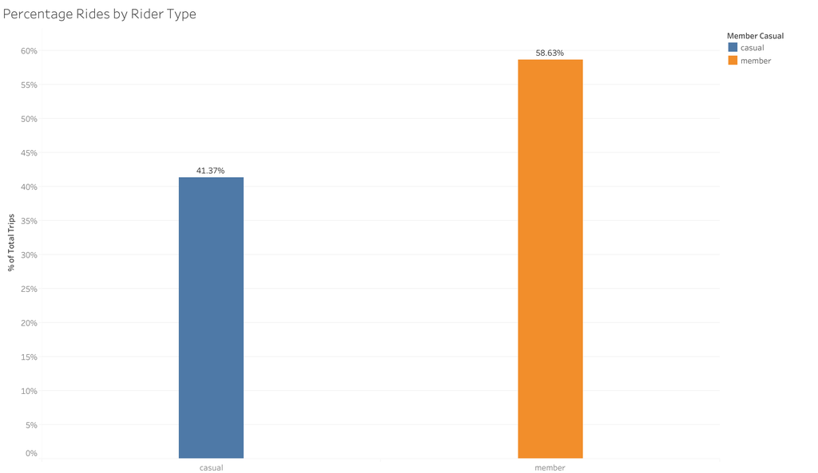

```r
knitr::include_graphics("Percentage of Rides by Rider Type_1.png")
```

#### Monthly Total Rides by Rider

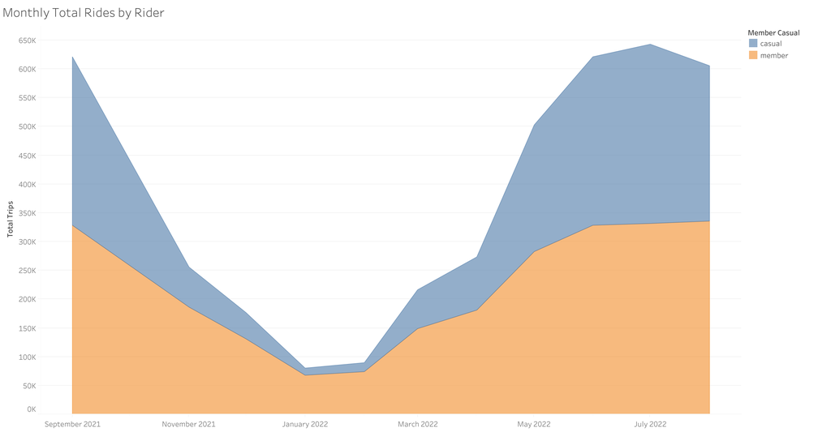

```r
knitr::include_graphics("Monthly Total Rides by Rider_2.png")
```

#### Daily Ride Totals by Rider

Moving from a monthly view to the weekly, we find that Members bike usage is heaviest during the week whereas the highest usage for Casual riders is on the weekends.

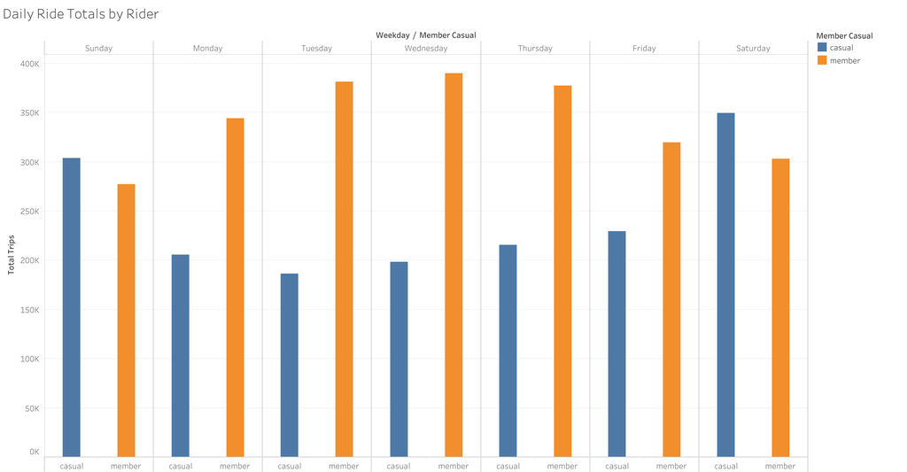

```r
knitr::include_graphics("Daily Ride Totals by Rider_3.png")
```

#### Daily Average Ride Length by Rider Type

Casual riders had an average ride of 36 minutes, almost three times the average ride length of Members. Members had an average ride length of 13 minutes.

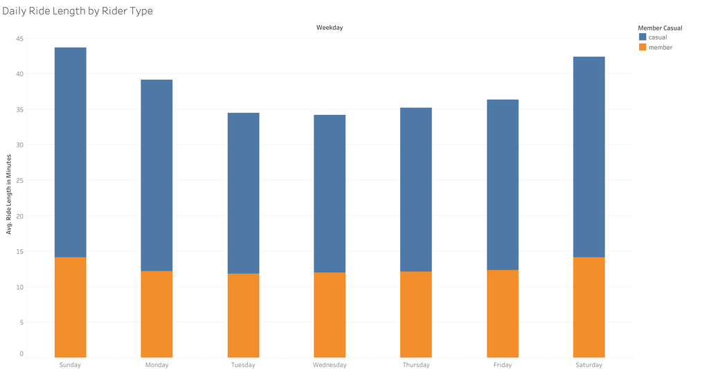

```r
knitr::include_graphics("Daily Ride Length by Rider Type_4.png")
```

#### Bike Preference

When it comes to bike preference for our customers, Classic Bike was the most used by both Members (40.5%) and Casual riders (22.5%). Classic bikes are being used 63% of the time overall. Electric bikes were the second most popular, being used by our Members 18% of the time and Casual riders 14% of the time. Electric bikes make up nearly a third of all bike usage. Docked bikes were only being used ~5% of tthe time and only by our Casual riders.

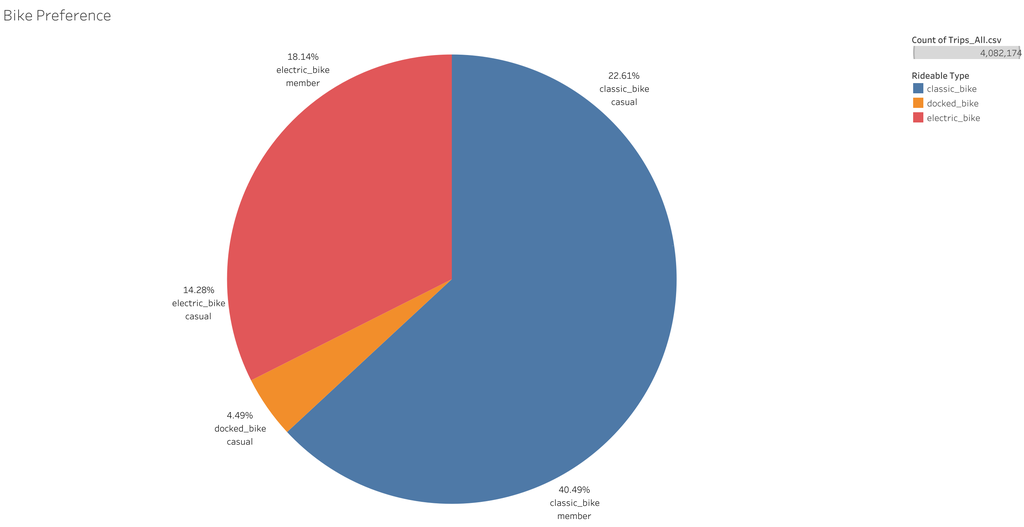

```r
knitr::include_graphics("Bike Preference_8.png")
```

#### Average Bike Usage by Time of Day

When looking at bike usage by time of day, we see that Member usage has a spike at 8am and 5pm while Casual riders have a slow build to a 5pm peak usage. This also shows that, overall, lunch time to 7pm is the heaviest block of usage with 4pm - 7pm being the busiest time segment

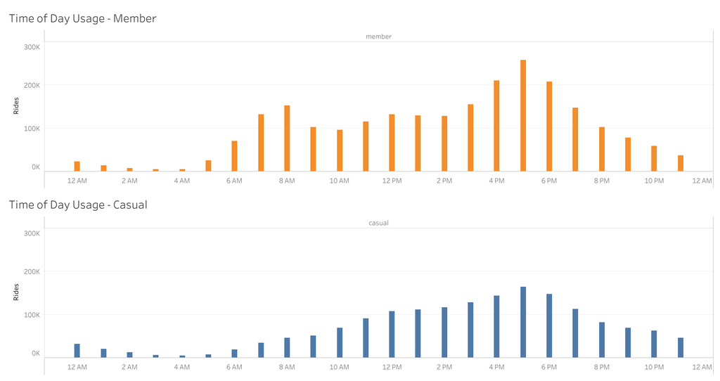

```r
knitr::include_graphics("Time of Day Usage_9.png")
```

### Step 6: Act

#### Suggestions / Recommendations

- Offer a Loyalty discount to upgrade to an annual membership based on their individual history with using the bike-share provided by Cyclistic.
- Offer an upgrade discount for Casual riders based on their individual amount of usage
- Create a survey for Casual riders to further understand their bike needs and usage.

#### Beyond the current data

- It would be great to know the percentage breakdown of single-ride usage to full-day pass usage for the Casual riders. Having this information could help guide the analysis and recommendations for coverting Casual riders to Members.
- We know that there are 5,824 bikes in the Cyclistic network. What we don’t have data on is the breakdown of how many of each bike are in Cyclists rotattional inventory. Having this information could be useful in considering whether adding more of the popular bike types in the busiest locations would help convert Casual riders to an annual membership.